# Module_01_Lesson_03 Solution

Romil Shah

05-15-2016

```r
twitterdata<-read.csv(file="C:/Users/rams1/Desktop/DSCS6030/Module_01/M01_quasi_twitter.csv")
require(ggplot2)
```

## How is the data distributed? What are the summaries?

#### (1) As per creation month-day-year

```
##    Min. 1st Qu.  Median    Mean 3rd Qu.    Max.
##   1.000   3.000   6.000   6.069   9.000  12.000
```

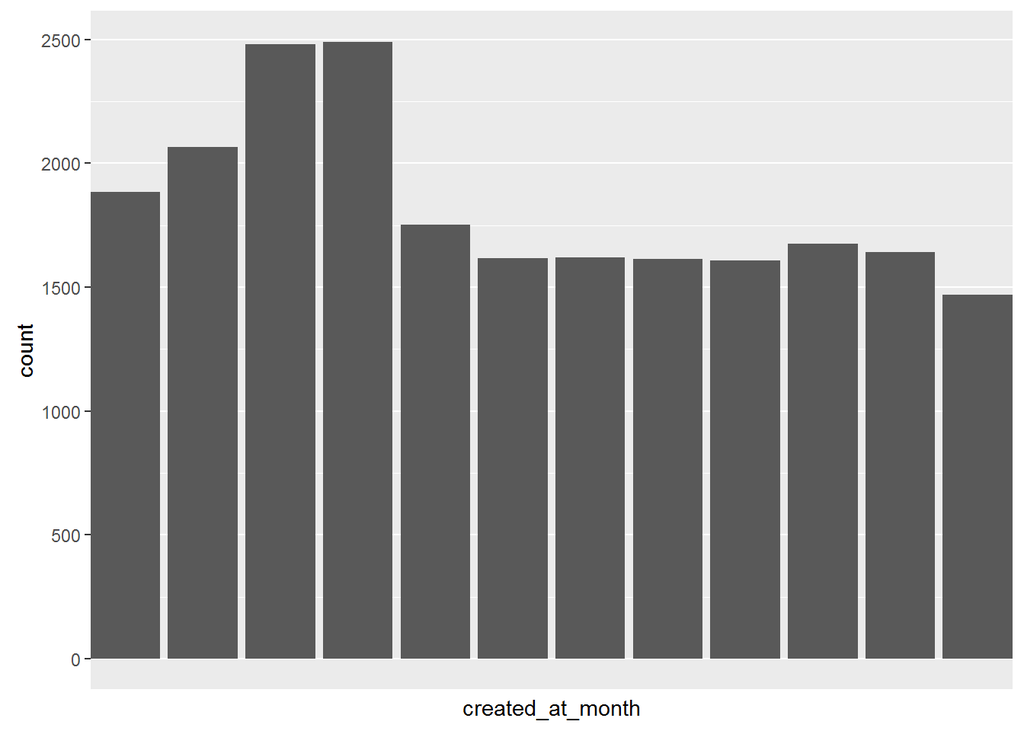

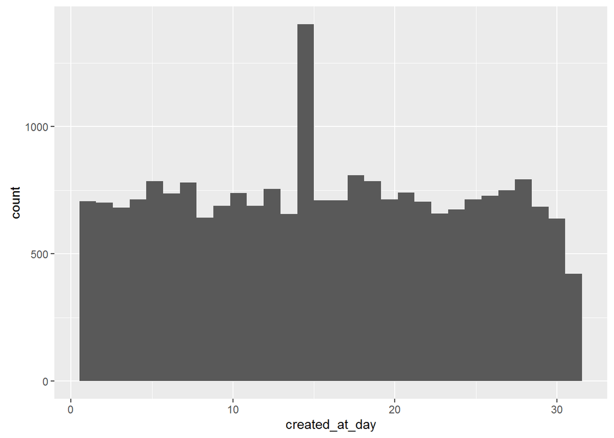

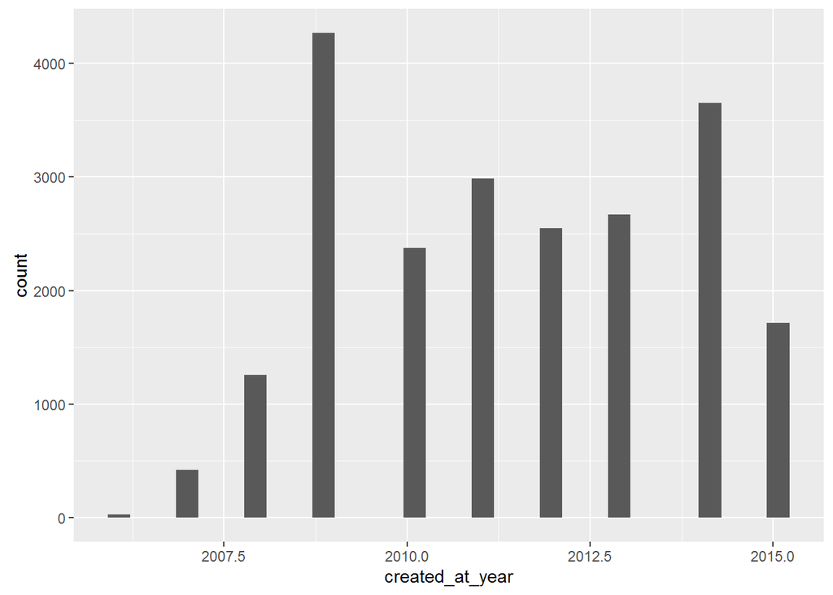

#### (2) As per Twitter data by country

```r
summary(twitterdata$country)
```

```
##              Germany            Argentina            Australia
##                   54                  190                  291
##              Belgium               Brazil               Canada
##                   56                  121                  943
##                Chile                China             Colombia
##                   61                   57                   50
##              Denmark                Earth              England
##                   59                  516                  467
##       European Union              Finland               France
##                   58                  110                  180
##              Germany               Greece            Hong Kong
##                  151                   59                   60
##                India              Ireland               Israel
##                  890                  171                   52
##                Italy                Japan                Kenya
##                  116                  162                  117
##               Kuwait           Luxembourg             Malaysia
##                   49                   62                   55
##               Mexico          Netherlands              Nigeria
##                  236                  170                  132
##               Panama          Philippines             Portugal
##                   59                   53                   49
##               Russia             Scotland            Singapore
##                   63                   57                   53
##         South Africa                Spain               Sweden
##                  183                  283                  123
##          Switzerland               Turkey United Arab Emirates
##                  115                   73                   56
##       United Kingdom                  USA
##                  149                14905
```

#### (3) As per Friends_count

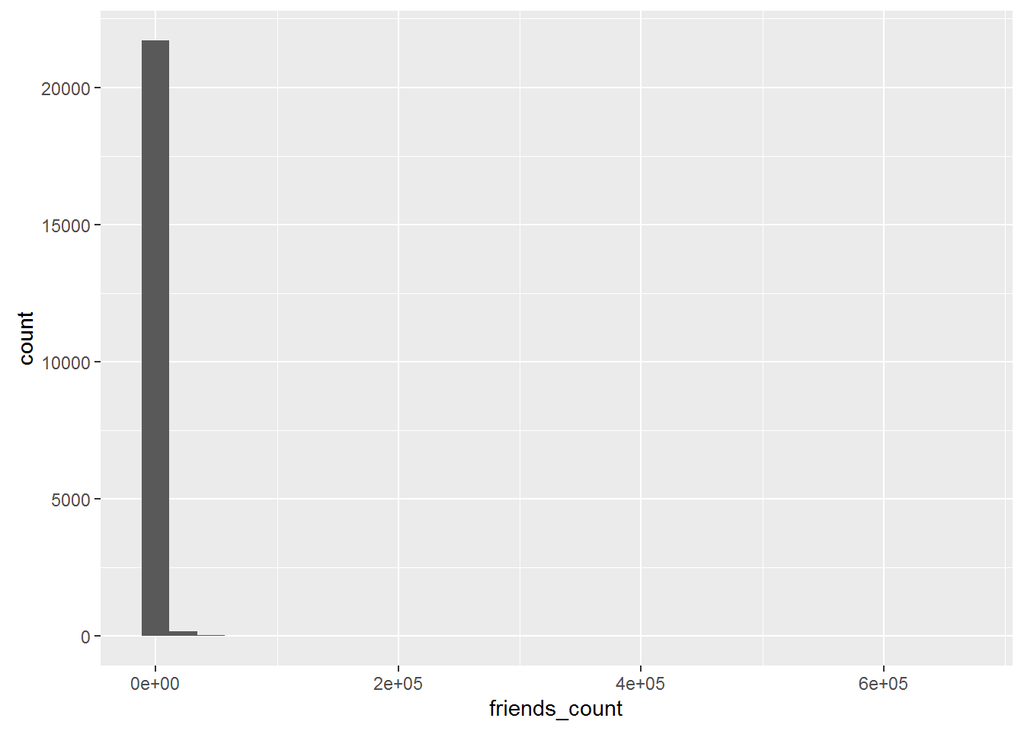

```r
qplot(data=twitterdata, x=friends_count)
```

```r
summary(twitterdata$friends_count)
```

```
##    Min. 1st Qu.  Median    Mean 3rd Qu.    Max.
##     -84     123     324    1058     849  660500
```

#### (4) As per gender

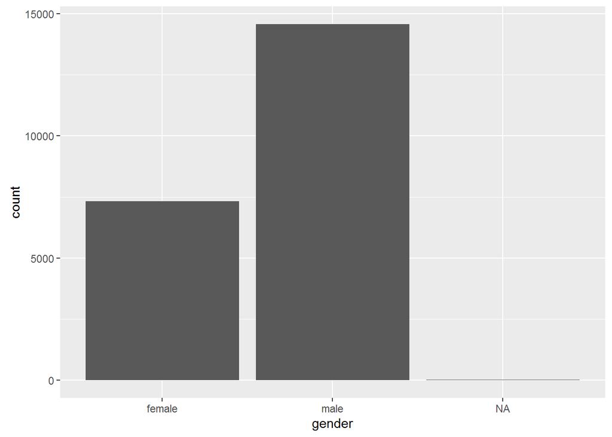

```r
qplot(data=twitterdata, x=gender)
```

```r
summary(twitterdata$gender)
```

```
## female   male   NA's
##   7319  14569     28
```

In the same way other columns can be used to classify the type of distribution of the data.

## Anomolies or Outliers

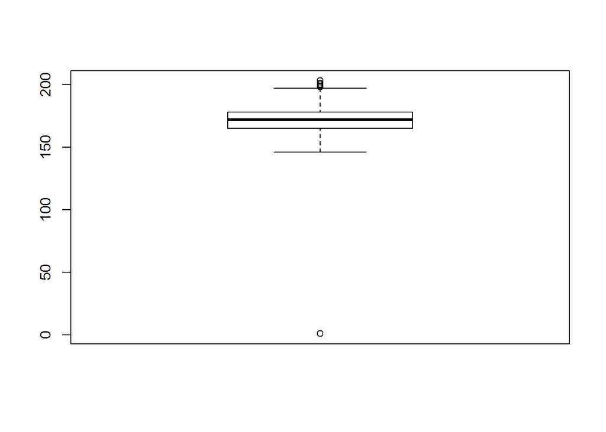

```r
boxplot(twitterdata$height)
```

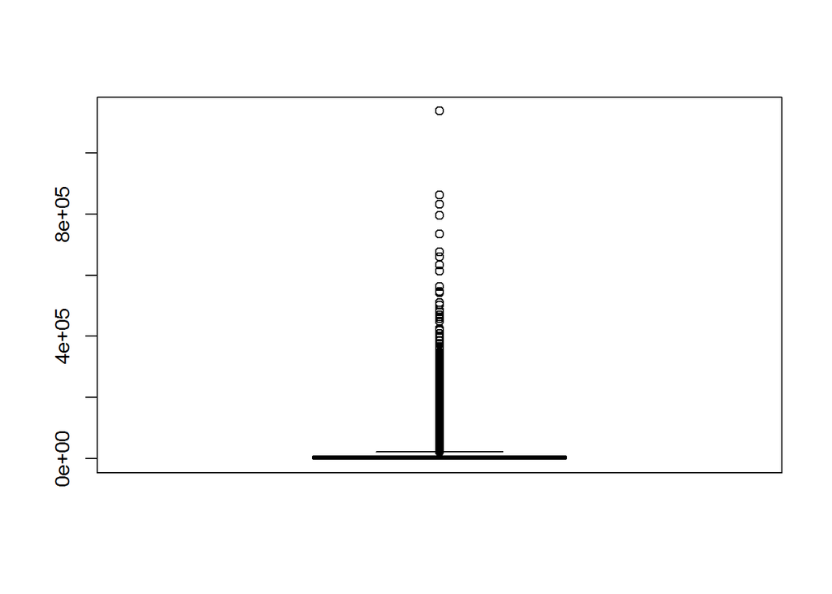

```r
boxplot(twitterdata$statuses_count)
```

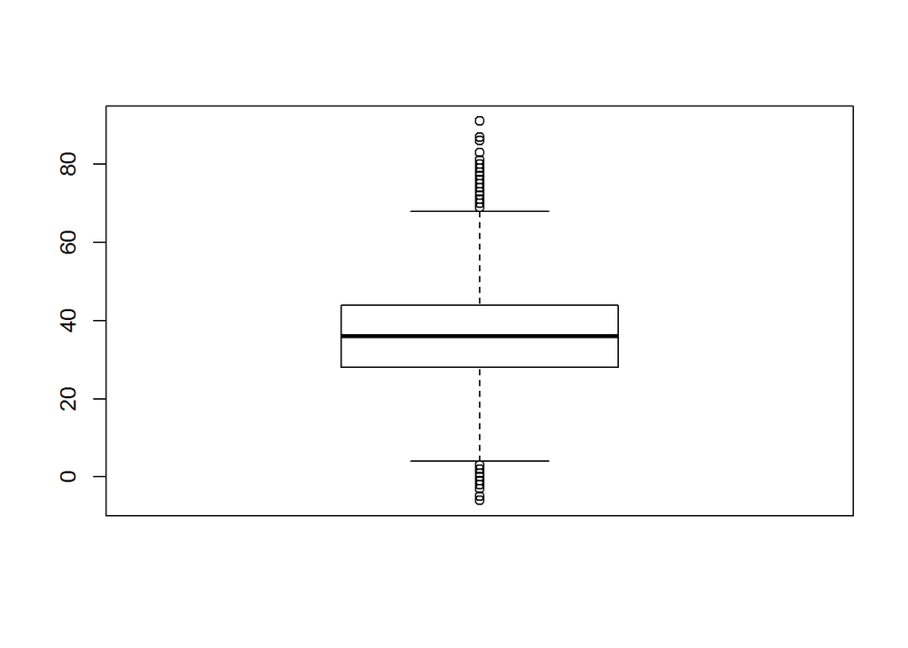

```r
boxplot(twitterdata$age)
```

There can be seen some outliers for all the box plots.

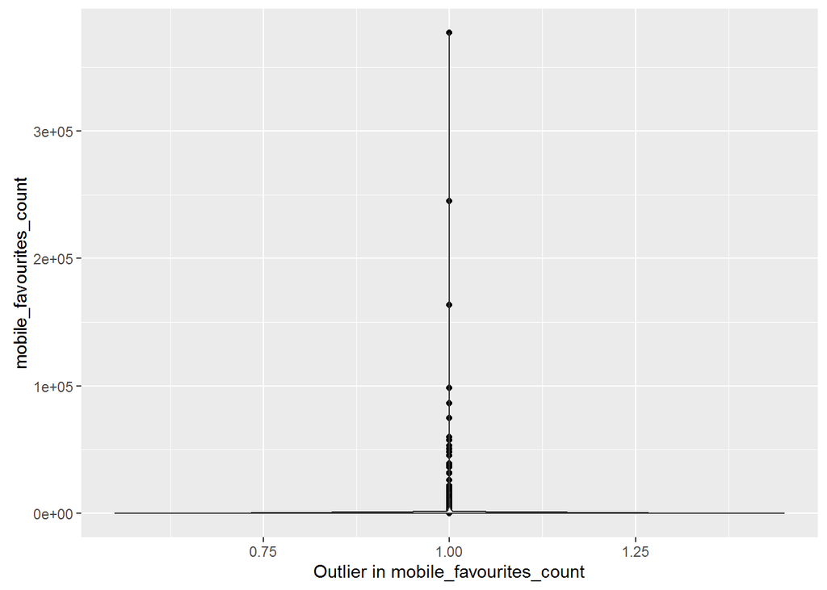

```r
qplot(1,mobile_favourites_count, data=twitterdata,xlab = "Outlier in mobile_favourites_count")+geom_violin()
```

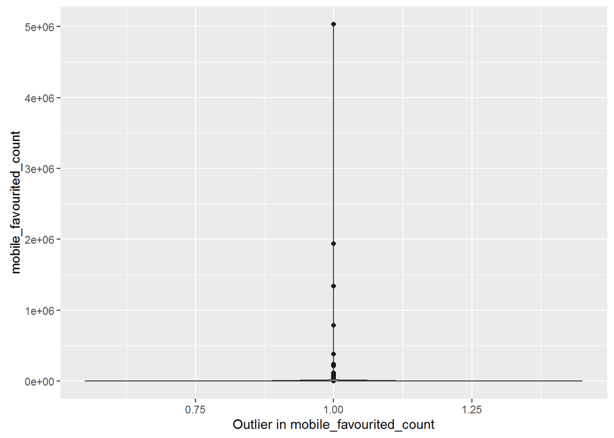

```r
qplot(1,mobile_favourited_count, data=twitterdata,xlab = "Outlier in mobile_favourited_count")+geom_violin()
```

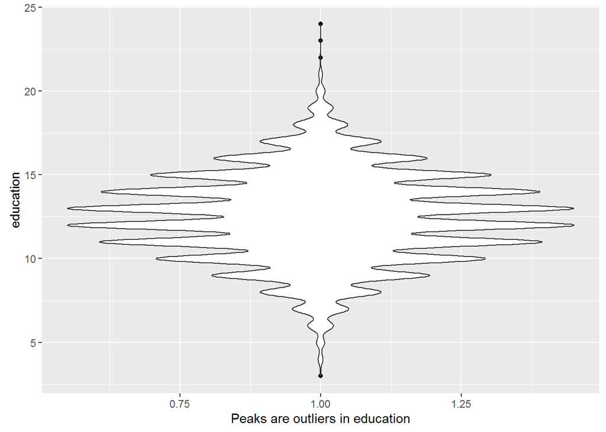

```r
qplot(1,education, data=twitterdata,xlab = "Peaks are outliers in education")+geom_violin()
```

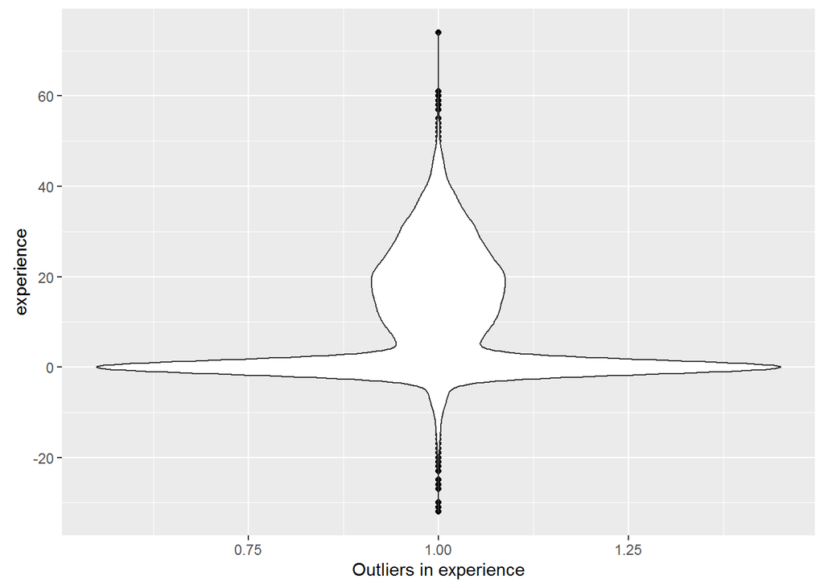

```r
qplot(1,experience, data=twitterdata,xlab = "Outliers in experience")+geom_violin()
```

## Can you identify the following:

- useful raw data and transforms (e.g. log(x))
- data quality problems
- outliers
- subsets of interest

One of the useful data transform can be for friends_count

It looks like a fat-tailed distribution. This implies that there is a small subset of users who have lot of friends, but most users don’t have many. This can be visualized easily on a log-scaled plot.

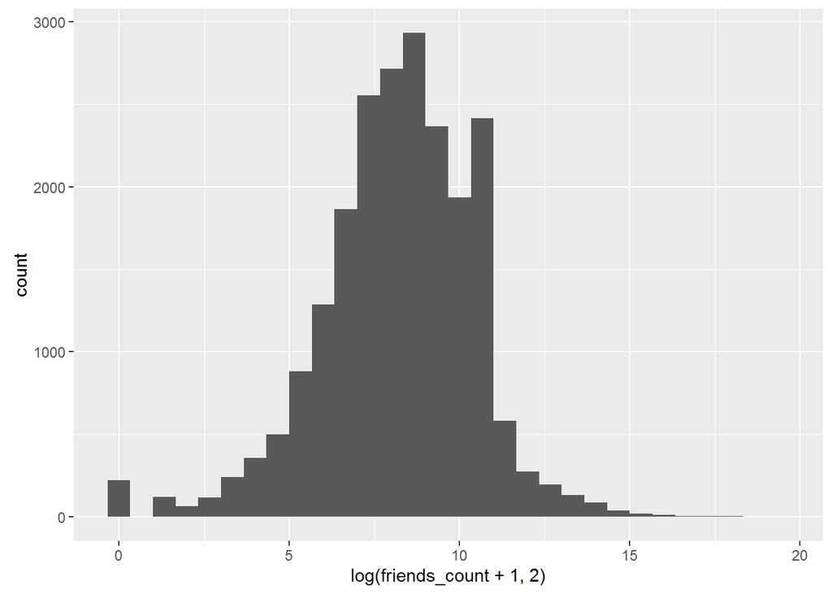

```r
qplot(x=log(friends_count+1,2), data=twitterdata)
```

Similarly, for favourites_count, we can visualize subset of data better using log-scaled plot.

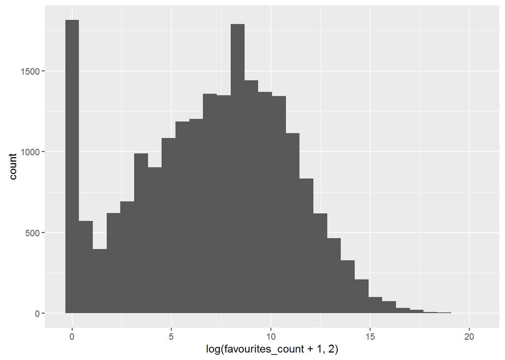

```r
qplot(x=log(favourites_count+1,2), data=twitterdata)
```

Some data quality problems are

- negative values in age, experince and friends_count. This can be infered from box plots/violin plots
- Fake age entries (zero)

## Functional Relationships

Some of the functional relationships that I found:

Functional relationshp between age and wage.

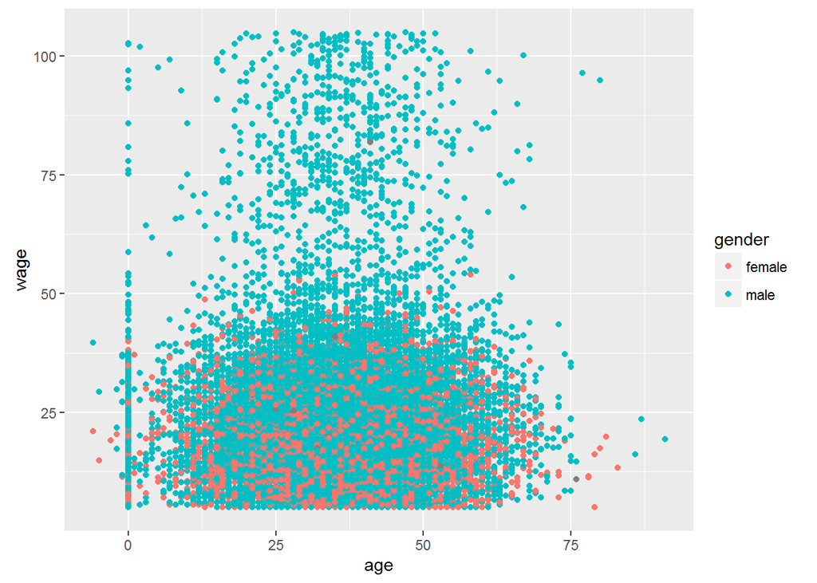

```r
ggplot(twitterdata, aes(x = age, y = wage, colour=gender)) + geom_point()
```